# SMART Indicator Report: Bottom Temperature - in situ

## Indicator name

Bottom Temperature - in situ

Includes variable(s): bottom temp anomaly in situ, reference bt in situ (1981-2010), reference sst in situ (1981-2010), sst anomaly in situ

## Indicator brief description

The data presented here are time series of regional average bottom temperature anomalies from ship-based measurements made on the Northeast Continental Shelf.

## Indicator visualization

No response

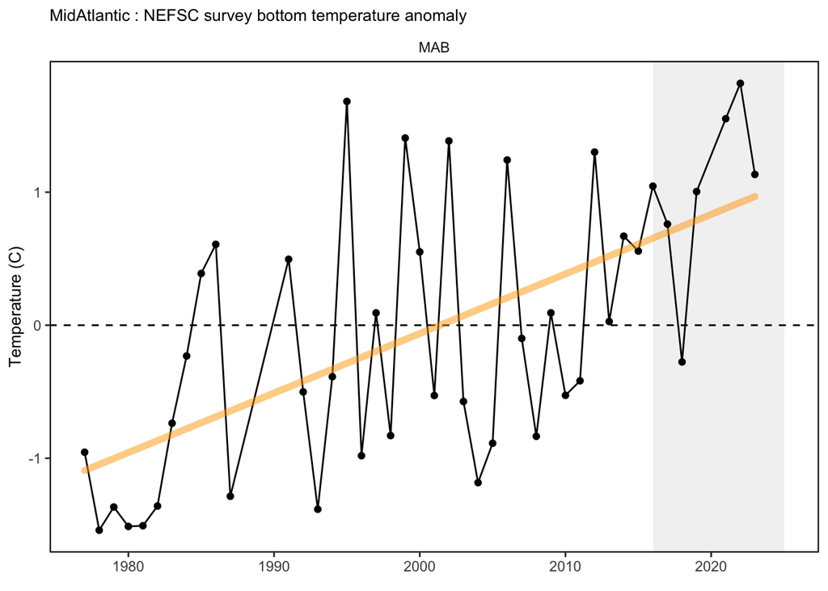

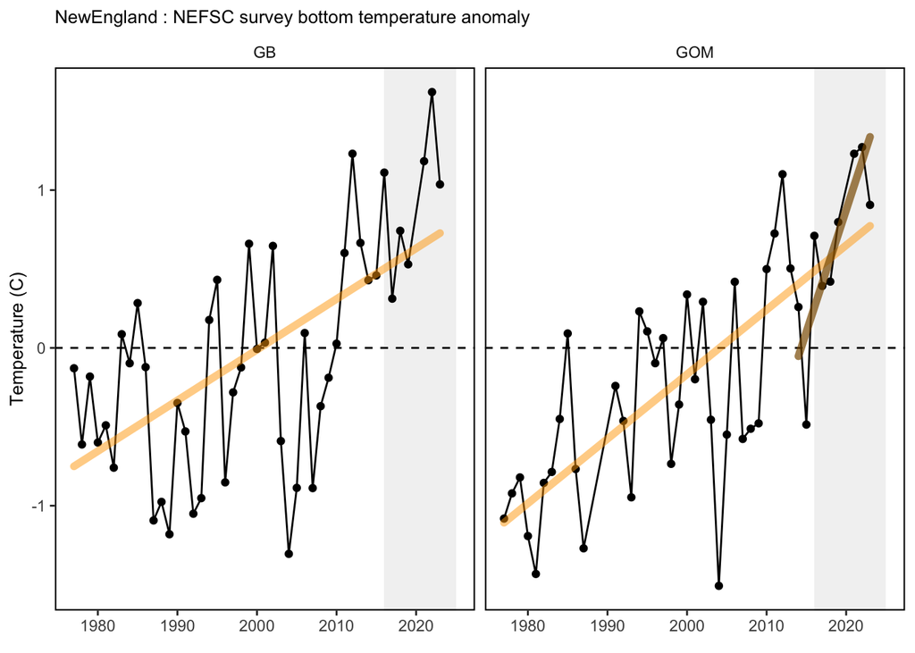

## Indicator documentation

### Are indicators available for others to use (data downloadable)?

```
## Yes
```

#### Where can indicators be found?

```
## Data: https://noaa-edab.github.io/ecodata/index.html
## Description:  https://noaa-edab.github.io/catalog/bottom_temp_insitu.html
## Technical documentation:  https://noaa-edab.github.io/tech-doc/bottom_temp_insitu.html
```

#### Who is the contact?

Paula.Fratantoni@noaa.gov

### Gather indicator statistics

#### Units

```
## degreesC
```

#### Length of time series, start and end date, periodicity

General overview: Annual

Indicator specifics:

| Indicator | EPU | StartYear | EndYear | NumYears | MissingYears |
| --- | --- | --- | --- | --- | --- |
| bottom temp anomaly in situ | GB | 1977 | 2023 | 46 | 1 |
| bottom temp anomaly in situ | GOM | 1977 | 2023 | 43 | 4 |
| bottom temp anomaly in situ | MAB | 1977 | 2023 | 43 | 4 |
| bottom temp anomaly in situ | SS | 1977 | 2023 | 41 | 6 |
| reference bt in situ (1981-2010) | GB | 1977 | 2023 | 46 | 1 |
| reference bt in situ (1981-2010) | GOM | 1977 | 2023 | 43 | 4 |
| reference bt in situ (1981-2010) | MAB | 1977 | 2023 | 43 | 4 |
| reference bt in situ (1981-2010) | SS | 1977 | 2023 | 41 | 6 |
| reference sst in situ (1981-2010) | GB | 1977 | 2023 | 46 | 1 |
| reference sst in situ (1981-2010) | GOM | 1977 | 2023 | 43 | 4 |
| reference sst in situ (1981-2010) | MAB | 1977 | 2023 | 43 | 4 |
| reference sst in situ (1981-2010) | SS | 1977 | 2023 | 43 | 4 |
| sst anomaly in situ | GB | 1977 | 2023 | 46 | 1 |
| sst anomaly in situ | GOM | 1977 | 2023 | 43 | 4 |
| sst anomaly in situ | MAB | 1977 | 2023 | 43 | 4 |
| sst anomaly in situ | SS | 1977 | 2023 | 43 | 4 |

#### Spatial location, scale and extent

General overview: by EPU

Indicator specifics:

| Indicator | EPU |
| --- | --- |
| bottom temp anomaly in situ | GB |
| bottom temp anomaly in situ | GOM |
| bottom temp anomaly in situ | MAB |
| bottom temp anomaly in situ | SS |
| reference bt in situ (1981-2010) | GB |
| reference bt in situ (1981-2010) | GOM |
| reference bt in situ (1981-2010) | MAB |
| reference bt in situ (1981-2010) | SS |
| reference sst in situ (1981-2010) | GB |
| reference sst in situ (1981-2010) | GOM |
| reference sst in situ (1981-2010) | MAB |
| reference sst in situ (1981-2010) | SS |
| sst anomaly in situ | GB |
| sst anomaly in situ | GOM |
| sst anomaly in situ | MAB |
| sst anomaly in situ | SS |

### Are methods clearly documented to obtain source data and calculate indicators?

```
## Yes
```

## Indicator analysis/testing or history of use

### What decision or advice processes are the indicators currently used in?

The bottom temperature index incorporates near-bottom temperature measurements collected on Northeast Fisheries Science Center (NEFSC) surveys between 1977-present. Early measurements were made using surface bucket samples, mechanical bathythermographs and expendable bathythermograph probes, but by 1991 the CTD – an acronym for conductivity temperature and depth – became standard equipment on all NEFSC surveys. Near-bottom refers to the deepest observation at each station that falls within 10 m of the reported water depth. Observations encompass the entire continental shelf area extending from Cape Hatteras, NC to Nova Scotia, Canada, inclusive of the Gulf of Maine and Georges Bank.

### What implications of the indicators are currently listed?

No response

## Comments

### Additional potential links to management in addition to uses listed above

### What additional work would be needed for the Council to use the indicator?

### What issues are caused if there is a gap or delay in data underlying the indicator